This notebook uses result files that were manually created from output cell contents in the indicated notebooks.

```python
import numpy as np
import pandas as pd
import seaborn as sns
import matplotlib.pyplot as plt
from sklearn.metrics import precision_recall_fscore_support
from sklearn.metrics import multilabel_confusion_matrix
from sklearn.metrics import confusion_matrix
from sklearn.metrics import roc_curve, auc
```

# Read in Results

```python
# prefix = './'

#
# Outputs under CSV header in `__3__run_inductive-conformal-prediction_experiments__cleared_output.ipynb`
ml = pd.read_csv(f'{prefix}standard_conformal_prediction_experiment_results__multilabel.csv')
# Outputs under CSV header in `__3__run_inductive-conformal-prediction_experiments__cleared_output.ipynb`
#

#
# Outputs under CSV header in `__4__run_crc-rcps-ltt_Model-Agnostic-Prediction-Interval-Estimator_experiments__cleared_output.ipynb`
mp = pd.read_csv(f'{prefix}mapie_multi-label_results_01.csv')
mp_025 = pd.read_csv(f'{prefix}mapie_multi-label_results_025.csv')

df_rcps_crc__tp_fp_tn_fn = pd.read_csv(f'{prefix}AoU_CRC-RCPS_TP-FP-TN-FN_at_0_1-and_0_25.csv')

df = pd.read_csv(f'{prefix}AoU_ICP_samples-averaged_recall_results.csv')
df_recall_cc_w_demo_ip = df[df['name']=='df_recall_cc_w_demo_ip'].drop('name', axis=1)
df_recall_cc_wo_demo_ip = df[df['name']=='df_recall_cc_wo_demo_ip'].drop('name', axis=1)
df_recall_nc_w_demo_ip = df[df['name']=='df_recall_nc_w_demo_ip'].drop('name', axis=1)
df_recall_nc_wo_demo_ip = df[df['name']=='df_recall_nc_wo_demo_ip'].drop('name', axis=1)
# Outputs under CSV header in `_4__run_crc-rcps-ltt_Model-Agnostic-Prediction-Interval-Estimator_experiments__cleared_output.ipynb`
#

#
# Outputs under CSV header in `__5__icp_vs_crc-and-rcps__cleared_output.ipynb`
df = pd.read_csv(f'{prefix}AoU_ICP_prediction-set_size_at-0_1-and-0_25.csv')
df_result_cc_w_demo_ip = df[df['name']=='df_result_cc_w_demo_ip'].drop('name', axis=1)
df_result_cc_wo_demo_ip = df[df['name']=='df_result_cc_wo_demo_ip'].drop('name', axis=1)
df_result_nc_w_demo_ip = df[df['name']=='df_result_nc_w_demo_ip'].drop('name', axis=1)
df_result_nc_wo_demo_ip = df[df['name']=='df_result_nc_wo_demo_ip'].drop('name', axis=1)

df = pd.read_csv(f'{prefix}AoU_CRC-RCPS_prediction-set_size_at-0_1.csv')
df_result_ml_wo = df[df['name']=='df_result_ml_wo'].drop('name', axis=1)
df_result_ml_wd = df[df['name']=='df_result_ml_wd'].drop('name', axis=1)

df = pd.read_csv(f'{prefix}AoU_ICP_samples-averaged_precision_results.csv')
df_precision_cc_w_demo_ip = df[df['name']=='df_precision_cc_w_demo_ip'].drop('name', axis=1)
df_precision_cc_wo_demo_ip = df[df['name']=='df_precision_cc_wo_demo_ip'].drop('name', axis=1)
df_precision_nc_w_demo_ip = df[df['name']=='df_precision_nc_w_demo_ip'].drop('name', axis=1)
df_precision_nc_wo_demo_ip = df[df['name']=='df_precision_nc_wo_demo_ip'].drop('name', axis=1)

df_icp__tp_fp_tn_fn = pd.read_csv(f'{prefix}AoU_ICP_TP-FP-TN-FN_at-0_1-and-0_25.csv')
# Outputs under CSV header in `__5__icp_vs_crc-and-rcps__cleared_output.ipynb`
#

#
# Outputs under CSV header in `__4__run_crc-rcps-ltt_Model-Agnostic-Prediction-Interval-Estimator_experiments__cleared_output.ipynb`
# Read in experiment run 32 (i=31) y_pred/y_true
df = pd.read_csv(f'{prefix}base_LSTM_test_results__run_index_31_w_demographics.csv')
# Outputs under CSV header in `_4__run_crc-rcps-ltt_Model-Agnostic-Prediction-Interval-Estimator_experiments__cleared_output.ipynb`
#
```

# Review a Base LSTM Model

(Multilabel LSTM using time-series and demographic predictors)

```python
### Get base LSTM (i=31) predictions/probabilities
y_score = df.pivot(index="example_idx", columns="label_idx", values="y_pred_prob_base_clf")
y_pred = (y_score >= 0.5).astype(int).to_numpy()
y_score = y_score.to_numpy()

# Get ground truth labels and correlation matrix
y_true = df.pivot(index="example_idx", columns="label_idx", values="y_true")
y_true.columns = ['Anxiety', 'Depression', 'No Disorder']
correlation_matrix = y_true.corr()  # Compute the correlation matrix
y_true = y_true.to_numpy()
```

## Correlation Matrix

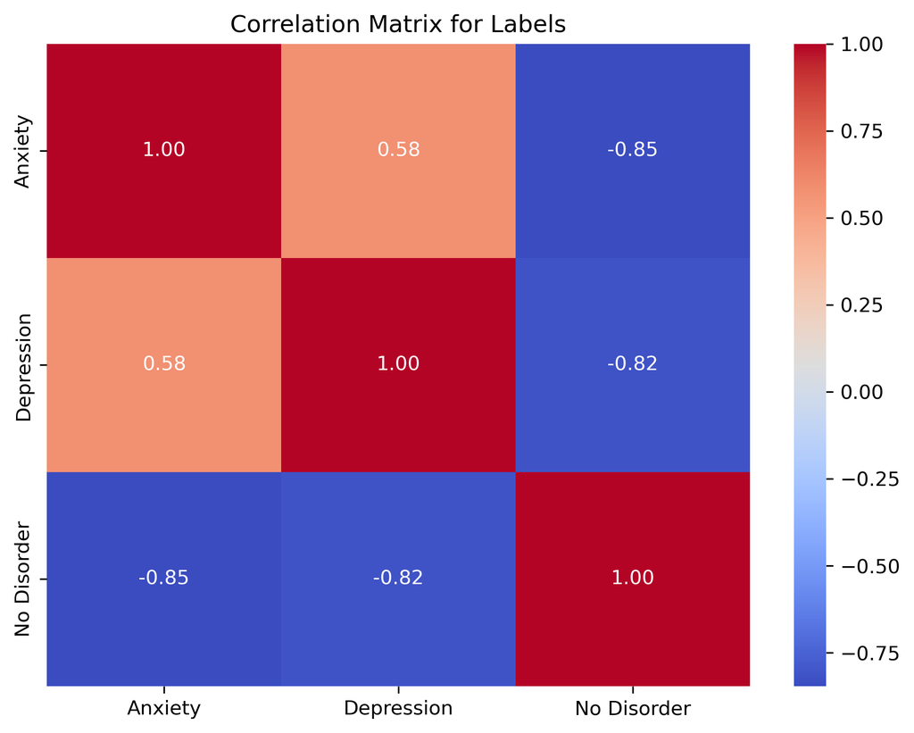

```python
# Plot the correlation matrix
plt.figure(figsize=(8, 6), dpi=300)

sns.heatmap(correlation_matrix, annot=True, cmap='coolwarm', fmt=".2f")
plt.title("Correlation Matrix for Labels")

# Save the figure with high resolution
plt.savefig('label_correlation_matrix_from_run_idx_31__with_demographics__publication_quality_plot.png', bbox_inches='tight')

plt.show()
```

## Confusion Matrix

### Individual Label Confusion Matrices

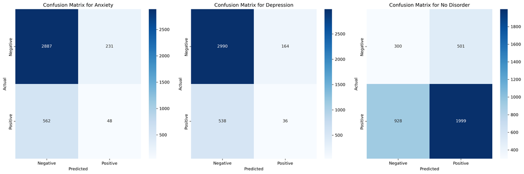

```python
# Generate confusion matrices for each label
conf_matrices = multilabel_confusion_matrix(y_true, y_pred, labels=[0, 1, 2])

# Set figure size
fig, axs = plt.subplots(1, 3, figsize=(18, 6), dpi=300)

# Print confusion matrix per label
for i, label in enumerate(['Anxiety', 'Depression', 'No Disorder']):

    # Visualize the confusion matrix for a single label (e.g., Anxiety)
    sns.heatmap(conf_matrices[i], annot=True, fmt="d", cmap="Blues", xticklabels=["Negative", "Positive"], yticklabels=["Negative", "Positive"], ax=axs[i])
    axs[i].set_title(f"Confusion Matrix for {label}")
    axs[i].set_xlabel("Predicted")
    axs[i].set_ylabel("Actual")

# Adjust layout for better spacing
plt.tight_layout()

# Save the figure with high resolution
plt.savefig('individual_label_confusion_matrices__base_LSTM_from_run_idx_31__with_demographics__publication_quality_plot.png', bbox_inches='tight')

plt.show()
```

### Overall Multilabel Confusion Matrix

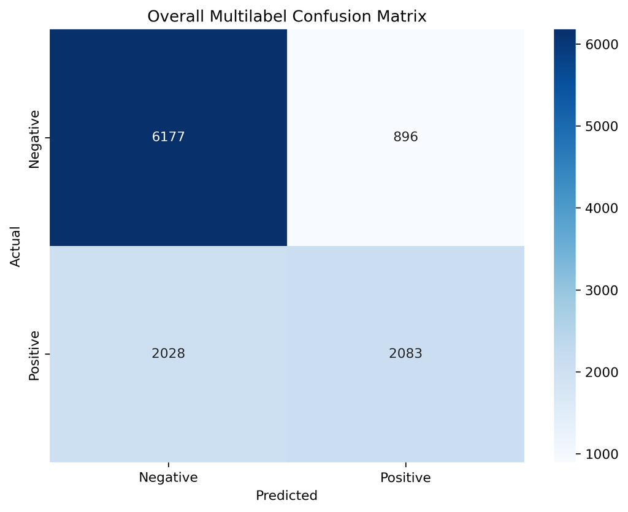

```python
# Flatten the arrays
y_true_flat = y_true.ravel()
y_pred_flat = y_pred.ravel()

# Compute the confusion matrix
conf_matrix = confusion_matrix(y_true_flat, y_pred_flat)

# Visualize the confusion matrix for a single label (e.g., Anxiety)
plt.figure(figsize=(8, 6), dpi=300)
sns.heatmap(conf_matrix, annot=True, fmt="d", cmap="Blues", xticklabels=["Negative", "Positive"], yticklabels=["Negative", "Positive"])
plt.title("Overall Multilabel Confusion Matrix")
plt.xlabel("Predicted")
plt.ylabel("Actual")

# Save the figure with high resolution
plt.savefig('overall_confusion_matrices__base_LSTM_from_run_idx_31__with_demographics__publication_quality_plot.png', bbox_inches='tight')

plt.show()
```

## Precision, Recall, and F1 Scores

### Overall Scores

```python
df['y_true']=df['y_true'].astype(int)
df['y_pred']=df['y_pred'].astype(int)
df_pivot = df.pivot(index=["run", "example_idx"], columns="label_idx")

# Flatten MultiIndex columns
df_pivot.columns = [f"{col[0]}_label{col[1]}" for col in df_pivot.columns]

# Reset index for a clean look
df_pivot = df_pivot.reset_index()

y_true = df_pivot.iloc[:, 2:5].to_numpy()
y_pred = df_pivot.iloc[:, 8:11].to_numpy()

precision_micro, recall_micro, f1_micro, _ = precision_recall_fscore_support(y_true, y_pred, average='micro')

print('---')
print('Micro Averaging:')
print('Precision:', precision_micro)
print('Recall:   ', recall_micro)
print('F1 Score: ', f1_micro)
print('---')
```

```
---
Micro Averaging:
Precision: 0.6992279288351796
Recall:    0.5066893699829725
F1 Score:  0.5875881523272214
---
```

### Per-Label Scores

```python
# Convert probabilities to binary predictions; here we use 0.5 as the threshold.
df['y_pred'] = (df['y_pred_prob_base_clf'] >= 0.5).astype(int)

# Initialize a dictionary to store metrics for each label.
metrics = {}

labels = ['Anxiety', 'Depression', 'No Disorder']

# Loop over each unique label
for label in df['label_idx'].unique():
    subset = df[df['label_idx'] == label]
    precision, recall, f1, _ = precision_recall_fscore_support(
        subset['y_true'], subset['y_pred'], average='binary'
    )
    metrics[labels[int(label)]] = {'precision': precision, 'recall': recall, 'f1': f1}

pd.DataFrame(metrics)
```

|  | Anxiety | Depression | No Disorder |
| --- | --- | --- | --- |
| precision | 0.172043 | 0.180000 | 0.799600 |
| recall | 0.078689 | 0.062718 | 0.682952 |
| f1 | 0.107987 | 0.093023 | 0.736687 |

## Micro-Averaged ROC Curve for Base LSTM

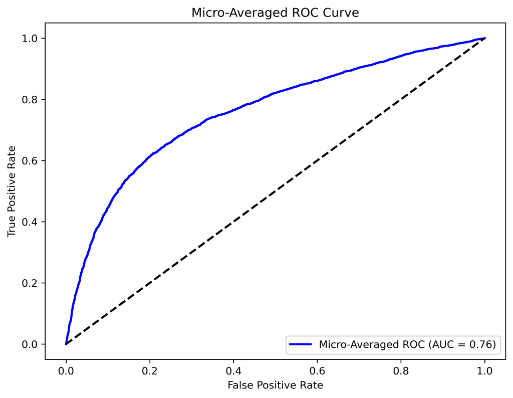

```python
# Compute micro-average ROC curve and AUC
fpr_micro, tpr_micro, _ = roc_curve(y_true.ravel(), y_score.ravel())
roc_auc_micro = auc(fpr_micro, tpr_micro)

# Plot the micro-average ROC curve
plt.figure(figsize=(8, 6), dpi=300)
plt.plot(fpr_micro, tpr_micro, label=f'Micro-Averaged ROC (AUC = {roc_auc_micro:.2f})', color='blue', lw=2)

# Plot diagonal line
plt.plot([0, 1], [0, 1], 'k--', lw=2)

# Plot formatting
plt.xlabel('False Positive Rate')
plt.ylabel('True Positive Rate')
plt.title('Micro-Averaged ROC Curve')
plt.legend(loc='lower right')

# Save the figure with high resolution
plt.savefig('micro-averaged_ROC_curve__base_LSTM_from_run_idx_31__with_demographics__publication_quality_plot.png', bbox_inches='tight')

plt.show()
```

# Multi-Label Binary ICP

(ICP=Inductive Conformal Prediction)

## Coverage

- Out of 200 models
  - 100 time-series + demographics
  - 100 time-series

### Overall

(Conformal Prediction contains ground truth label %)

Below shows user-specified coverage of 90% was met by both naive and class-conditional ICP

```python
temp=ml[ml['class_conditional']==False].describe().iloc[[1,5],[2]].T
temp.columns=['mean','median']
df=ml[ml['class_conditional']==True].describe().iloc[[1,5],[2]].T
df.columns=['mean_cc','median_cc']
pd.concat([temp,df], axis=1)
```

|  | mean | median | mean_cc | median_cc |
| --- | --- | --- | --- | --- |
| cp_contains_true_label_percent | 0.900105 | 0.900242 | 0.90056 | 0.90103 |

### Naive vs Class-Conditional

`Class=True/False` (Present/Absent)

```python
temp=ml[ml['class_conditional']==False].describe().iloc[[1,5],[2,4,6,8,10,12,14]].T
temp.columns=['mean','median']
df=ml[ml['class_conditional']==True].describe().iloc[[1,5],[2,4,6,8,10,12,14]].T
df.columns=['mean_cc','median_cc']
df=pd.concat([temp,df], axis=1)
pd.DataFrame({'True': df.iloc[[2,4,6],:].mean(axis=0), 'False': df.iloc[[1,3,5],:].mean(axis=0)}).T
```

|  | mean | median | mean_cc | median_cc |
| --- | --- | --- | --- | --- |
| True | 0.591632 | 0.584458 | 0.901225 | 0.902116 |
| False | 0.980610 | 0.988508 | 0.900562 | 0.900439 |

Above shows overall coverage imbalance, over-covering `False` and under-covering `True` (**`False` is overrepresented in the dataset**).

Class-Conditional does not show this coverage imbalance.

##### Break-Down of Coverage Imbalance

```python
df
```

|  | mean | median | mean_cc | median_cc |
| --- | --- | --- | --- | --- |
| cp_contains_true_label_percent | 0.900105 | 0.900242 | 0.900560 | 0.901030 |
| cp_contains_true_label_percent_anxiety_false | 0.985180 | 0.988689 | 0.900661 | 0.900305 |
| cp_contains_true_label_percent_anxiety_true | 0.468639 | 0.463232 | 0.901126 | 0.902467 |
| cp_contains_true_label_percent_depression_false | 0.988661 | 0.992697 | 0.900102 | 0.899904 |
| cp_contains_true_label_percent_depression_true | 0.424817 | 0.410518 | 0.902131 | 0.903090 |
| cp_contains_true_label_percent_no_disorder_false | 0.967990 | 0.984137 | 0.900923 | 0.901107 |
| cp_contains_true_label_percent_no_disorder_true | 0.881442 | 0.879625 | 0.900419 | 0.900791 |

`Class=True/False` (Present/Absent)

#### Distribution of Coverage

`User-Specified Coverage = 0.9`

##### Definition `plot_icp_coverage_distribution()`

```python
import pandas as pd
import matplotlib.pyplot as plt
import seaborn as sns


def plot_icp_coverage_distribution(with_demographics: bool):
    """
    Plots the Naive/Class-Conditioonal ICP coverage densities for each label's Absence/Presence.

    The figure is arranged in 3 rows (one for each label/disorder) and 4 columns corresponding to:
    'CC: False\nGround Truth: Absent', 'CC: True\nGround Truth: Absent',
    'CC: False\nGround Truth: Present', and 'CC: True\nGround Truth: Present'.

    Parameters:
        with_demographics (bool): If True, plots for rows with demographics.
                                  If False, plots for rows without demographics.
    """
    df = ml.copy()

    # Filter the dataframe based on the demographics flag.
    demo_df = df[df['with_demographics'] == with_demographics]

    # Split the data by class_conditional for easy subsetting.
    groups = {
        False: demo_df[demo_df['class_conditional'] == False],
        True:  demo_df[demo_df['class_conditional'] == True]
    }

    # Define a mapping for each disorder.
    # For each disorder we provide a tuple for ground truth = False and ground truth = True.
    mapping = {
        'Anxiety': {
            False: ('base_contains_true_label_percent_anxiety_false', 'cp_contains_true_label_percent_anxiety_false'),
            True:  ('base_contains_true_label_percent_anxiety_true',  'cp_contains_true_label_percent_anxiety_true')
        },
        'Depression': {
            False: ('base_contains_true_label_percent_depression_false', 'cp_contains_true_label_percent_depression_false'),
            True:  ('base_contains_true_label_percent_depression_true',  'cp_contains_true_label_percent_depression_true')
        },
        'No Disorder': {
            False: ('base_contains_true_label_percent_no_disorder_false', 'cp_contains_true_label_percent_no_disorder_false'),
            True:  ('base_contains_true_label_percent_no_disorder_true',  'cp_contains_true_label_percent_no_disorder_true')
        }
    }

    # Define the four subplot conditions.
    # Each tuple is (class_conditional value, ground truth value)
    subplot_conditions = [
        (False, False),  # Column 1: CC False, GT Absent
        (True,  False),  # Column 2: CC True,  GT Absent
        (False, True),   # Column 3: CC False, GT Present
        (True,  True)    # Column 4: CC True,  GT Present
    ]

    # Define colors (colorblind-friendly) for Base and CP.
    colors = {'base': 'blue', 'cp': 'orange'}

    # Create a grid: 3 rows (one per label/disorder) and 4 columns (for the four conditions).
    # The figure size is set to approximate a 4:6 (height:width) ratio.
    fig, axs = plt.subplots(3, 4, figsize=(12, 8), sharex=True, sharey=True, dpi=300)

    # Define letters for subplots (a to l).
    letters = "abcdefghijkl"

    # Loop over each disorder (row) and each condition (column).
    for row_idx, (disorder, col_dict) in enumerate(mapping.items()):
        for col_idx, (cc_val, gt_val) in enumerate(subplot_conditions):
            ax = axs[row_idx, col_idx]
            # For the given disorder and ground truth value, get the base and CP column names.
            base_col, cp_col = col_dict[gt_val]

            # Subset the dataframe for the given class_conditional value.
            group = groups[cc_val]

            # Plot the density estimates for Base and CP.
            sns.kdeplot(group[base_col], ax=ax, color=colors['base'], label="Base", linewidth=2)
            sns.kdeplot(group[cp_col], ax=ax, color=colors['cp'], label="CP", linewidth=2)

            ax.set_xlim(-0.05, 1.05)
            ax.grid(True, linestyle='--', alpha=0.5)
            ax.axvline(x=0.9, color='red', linestyle='--', linewidth=1)

            # For the top row, add a title with the CC and Ground Truth combination.
            if row_idx == 0:
                label_class_value = 'Present' if gt_val else 'Absent'
                ax.set_title(f"CC: {cc_val}\nGT: {label_class_value}", fontsize=12)
            # On the leftmost column, label the row with the disorder.
            if col_idx == 0:
                ax.set_ylabel(disorder, fontsize=12)
            idx = row_idx * 4 + col_idx
            ax.text(0.02, 0.98, letters[idx], transform=ax.transAxes,
                    fontsize=12, fontweight='bold', va='top', ha='left')

            # Hide individual legends and x-labels to reduce clutter.
            ax.legend().set_visible(False)
            ax.set_xlabel('')

    # Create a single legend for the entire figure.
    handles = [
        plt.Line2D([], [], color=colors['base'], label='Base', linewidth=2),
        plt.Line2D([], [], color=colors['cp'], label='CP', linewidth=2),
        plt.Line2D([], [], color='red', linestyle='--', label='Coverage=0.9', linewidth=1)
    ]
    fig.legend(handles=handles, loc='upper right', fontsize=12)

    # Global labels and title.
    fig.text(0.5, 0.02, 'Coverage', ha='center', fontsize=14)
    fig.text(0.02, 0.5, 'Density', va='center', rotation='vertical', fontsize=14)
    demo_label = "With Demographics" if with_demographics else "Without Demographics"
    if with_demographics:
        fig.suptitle(f'Base Model Coverage vs Inductive Conformal Prediction', fontsize=16, y=0.97)
    else:
        fig.suptitle(f'Base Model Coverage vs ICP ({demo_label})', fontsize=16, y=0.98)

    plt.tight_layout(rect=[0.03, 0.03, 0.97, 0.95])
    plt.savefig(f'icp_coverage_of_each_labels_class_value_at_alpha-0_1-class_conditional_vs_non_{demo_label.replace(" ", "_").lower()}__publication_quality_plot.png', bbox_inches='tight')
    plt.show()
```

##### Plot ICP Coverage Distribution (`with_demographics=True`)

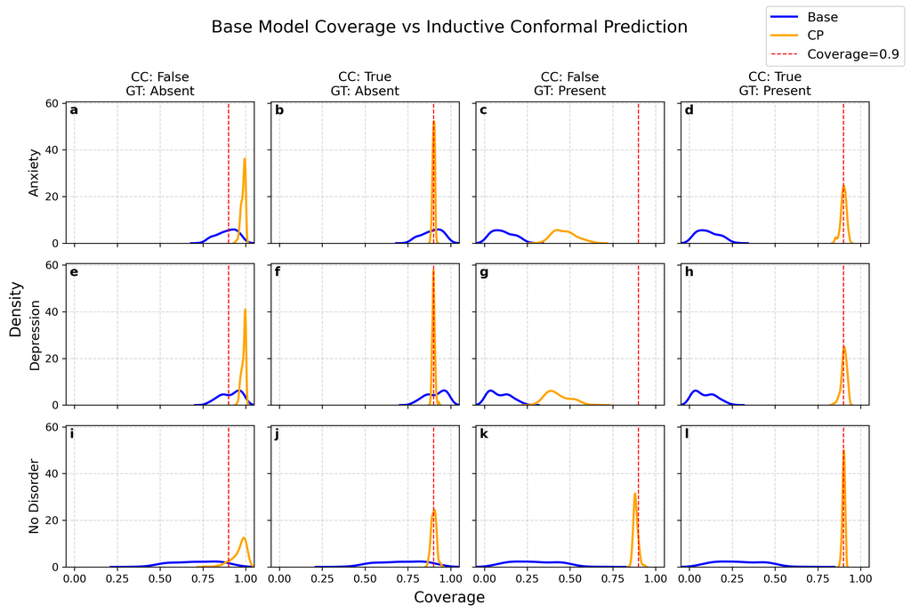

```python
plot_icp_coverage_distribution(with_demographics=True)
```

##### Plot ICP Coverage Distribution (`with_demographics=False`)

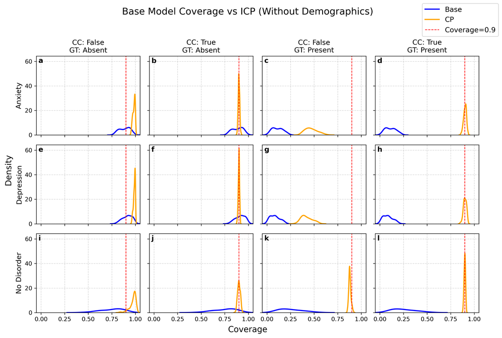

```python
plot_icp_coverage_distribution(with_demographics=False)
```

# ICP - Recall & Prediction-Set Size

## Observations NC/CC ICP vs CRC/RCPS

**Non-Conditional (NC)**  
**Class-Conditional (CC)**

- NC ICP Observed:
  - prediction-set size
    - similar/smaller vs CRC/RCPS
    - smaller vs CC ICP
  - recall
    - lower vs CRC/RCPS
    - lower vs CC ICP
- CC ICP Observed:
  - prediction-set size
    - larger vs CRC/RCPS
    - larger vs NC ICP
  - recall
    - similar vs CRC/RCPS
    - higher vs NC ICP

# ICP - Recall (`average='samples'`) - $\alpha$=0.1 / $\alpha$=0.25

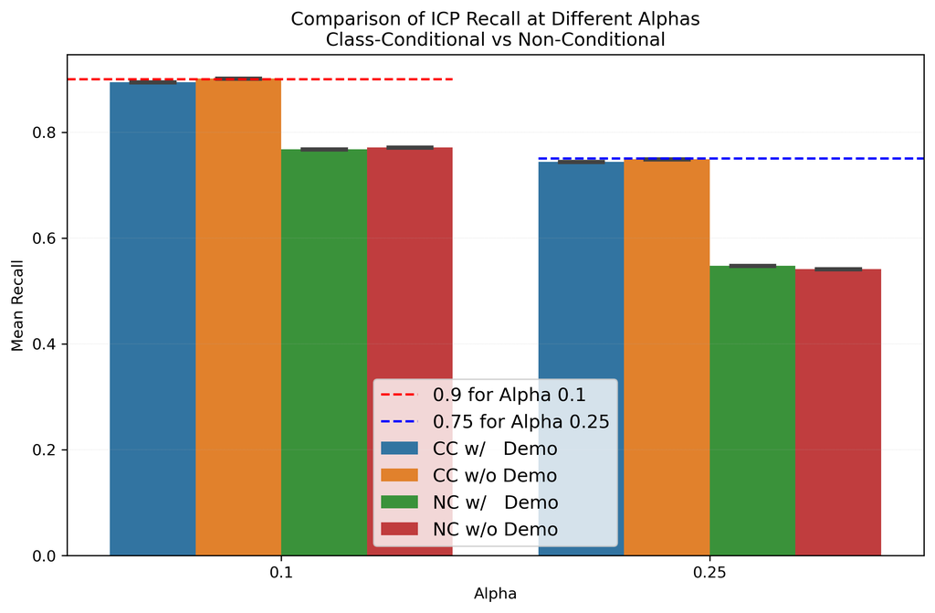

```python
import pandas as pd
import seaborn as sns
import matplotlib.pyplot as plt

# List of DataFrames
dfs = [df_recall_cc_w_demo_ip, df_recall_cc_wo_demo_ip, df_recall_nc_w_demo_ip, df_recall_nc_wo_demo_ip]

# Add a label to identify the source of each DataFrame
df_recall_cc_w_demo_ip['Source'] = 'CC w/   Demo'
df_recall_cc_wo_demo_ip['Source'] = 'CC w/o Demo'
df_recall_nc_w_demo_ip['Source'] = 'NC w/   Demo'
df_recall_nc_wo_demo_ip['Source'] = 'NC w/o Demo'

# Concatenate the DataFrames
df_concat = pd.concat(dfs)

df_concat = df_concat.rename(columns={'recall_alpha_0.1': '0.1', 'recall_alpha_0.25': '0.25'})

# Melt the DataFrame to long format for easier plotting with seaborn
df_melted = df_concat.melt(id_vars=['run', 'Source'],
                           value_vars=['0.1', '0.25'],
                           var_name='Alpha', value_name='Recall')

# Plot the bars
plt.figure(figsize=(10, 6), dpi=300)
ax = sns.barplot(data=df_melted, x='Alpha', y='Recall', hue='Source', capsize=.1)

# Add horizontal lines
ax.axhline(0.9, color='red', linestyle='--', xmin=0, xmax=0.45, label='0.9 for Alpha 0.1')
ax.axhline(0.75, color='blue', linestyle='--', xmin=0.55, xmax=1, label='0.75 for Alpha 0.25')

# Improving layout and readability
ax.grid(True, axis='y', which='both', linestyle='--', linewidth=0.1)
ax.legend(loc='best', fontsize=12)

# Add labels and title
plt.title('Comparison of ICP Recall at Different Alphas\nClass-Conditional vs Non-Conditional')
plt.ylabel('Mean Recall')
plt.xlabel('Alpha')

# Save the figure with high resolution
plt.savefig('icp_recall_at_alpha-0_1-and-0_25-class_conditional_vs_non_and_w_demographics_and_wo__publication_quality_plot.png', bbox_inches='tight')

# Display the plot
plt.show()
```

# Prediction Set Size - ICP & CRC/RCPS

## ICP vs CRC/RCPS

### With Demographics

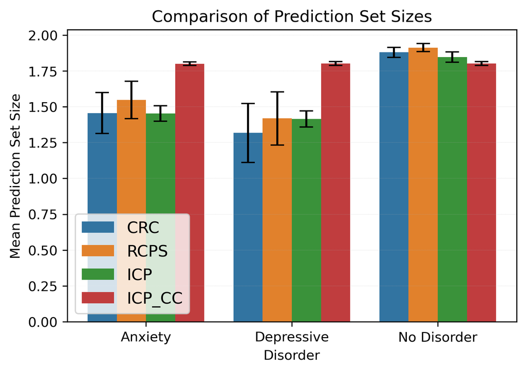

```python
import seaborn as sns
import matplotlib.pyplot as plt
import pandas as pd


# Prepare the data for seaborn
df_ml_wd_stats = df_result_ml_wd.drop('run', axis=1).groupby('label_idx').agg(['mean', 'std']).reset_index()
df_nc_w_demo_ip_stats = df_result_nc_w_demo_ip.drop(['run', 'pred_set_size_alpha_0.25'], axis=1).groupby('label_idx').agg(['mean', 'std']).reset_index()
df_cc_w_demo_ip_stats = df_result_cc_w_demo_ip.drop(['run', 'pred_set_size_alpha_0.25'], axis=1).groupby('label_idx').agg(['mean', 'std']).reset_index()

# Rename columns for easier plotting
df_ml_wd_stats.columns = ['label_idx', 'CRC', 'CRC_std', 'RCPS', 'RCPS_std']
df_nc_w_demo_ip_stats.columns = ['label_idx', 'ICP', 'ICP_std']
df_cc_w_demo_ip_stats.columns = ['label_idx', 'ICP_CC', 'ICP_CC_std']

# Merge the DataFrames
df_merged = pd.merge(df_ml_wd_stats[['label_idx', 'CRC', 'CRC_std', 'RCPS', 'RCPS_std']],
                     df_nc_w_demo_ip_stats[['label_idx', 'ICP', 'ICP_std']],
                     on='label_idx')

df_merged = pd.merge(df_merged,
                     df_cc_w_demo_ip_stats[['label_idx', 'ICP_CC', 'ICP_CC_std']],
                     on='label_idx')

# Map label_idx values
label_map = {0: 'Anxiety', 1: 'Depressive', 2: 'No Disorder'}
df_merged['label_idx'] = df_merged['label_idx'].map(label_map)

# Melt the DataFrame to long format
df_melted_mean = df_merged.melt(id_vars='label_idx',
                                value_vars=['CRC', 'RCPS', 'ICP', 'ICP_CC'],
                                var_name='Prediction Size', value_name='Mean Predicted Set Size')

df_melted_std = df_merged.melt(id_vars='label_idx',
                               value_vars=['CRC_std', 'RCPS_std', 'ICP_std', 'ICP_CC_std'],
                               var_name='Prediction Size', value_name='Std Dev')

# Match the melted data for error bars
df_melted_mean['Std Dev'] = df_melted_std['Std Dev']

# Plot the bars with error bars
plt.figure(figsize=(6, 4), dpi=300)
ax = sns.barplot(data=df_melted_mean, x='label_idx', y='Mean Predicted Set Size', hue='Prediction Size', capsize=.1)

# Add the error bars based on the correct positions of the bars
num_bars = len(df_melted_mean['label_idx'].unique())
for i in range(len(df_melted_mean)):
    # Get the position of each bar
    bar = ax.patches[i]
    # Calculate the center of the bar
    x = bar.get_x() + bar.get_width() / 2
    y = bar.get_height()
    # Add the error bar
    ax.errorbar(x=x, y=y, yerr=df_melted_mean.iloc[i]['Std Dev'], fmt='none', c='black', capsize=5)

# Improving layout and readability
ax.grid(True, axis='y', which='both', linestyle='--', linewidth=0.1)
ax.legend(loc='best', fontsize=12)


# Add labels and title
plt.title('Comparison of Prediction Set Sizes')
plt.ylabel('Mean Prediction Set Size')
plt.xlabel('Disorder')

# Save the figure with high resolution
plt.savefig('prediction-set_sizes_crc-rcps-icp_nc-icp_cc__with_demographics__publication_quality_plot.png', bbox_inches='tight')

# Display the plot
plt.show()
```

### Without Demographics

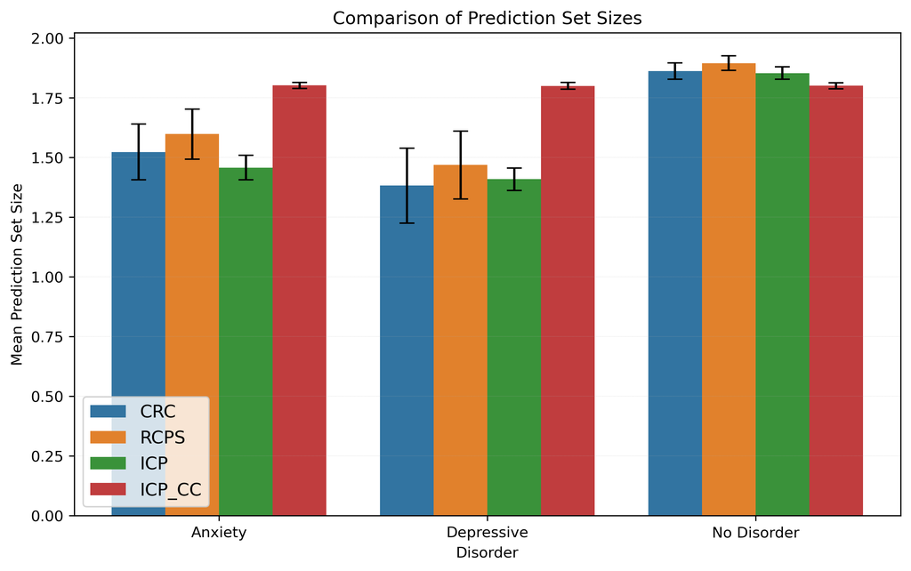

```python
import seaborn as sns
import matplotlib.pyplot as plt
import pandas as pd


# Prepare the data for seaborn
df_ml_wo_stats = df_result_ml_wo.drop('run', axis=1).groupby('label_idx').agg(['mean', 'std']).reset_index()
df_nc_wo_demo_ip_stats = df_result_nc_wo_demo_ip.drop(['run', 'pred_set_size_alpha_0.25'], axis=1).groupby('label_idx').agg(['mean', 'std']).reset_index()
df_cc_wo_demo_ip_stats = df_result_cc_wo_demo_ip.drop(['run', 'pred_set_size_alpha_0.25'], axis=1).groupby('label_idx').agg(['mean', 'std']).reset_index()

# Rename columns for easier plotting
df_ml_wo_stats.columns = ['label_idx', 'CRC', 'CRC_std', 'RCPS', 'RCPS_std']
df_nc_wo_demo_ip_stats.columns = ['label_idx', 'ICP', 'ICP_std']
df_cc_wo_demo_ip_stats.columns = ['label_idx', 'ICP_CC', 'ICP_CC_std']

# Merge the DataFrames
df_merged = pd.merge(df_ml_wo_stats[['label_idx', 'CRC', 'CRC_std', 'RCPS', 'RCPS_std']],
                     df_nc_wo_demo_ip_stats[['label_idx', 'ICP', 'ICP_std']],
                     on='label_idx')

df_merged = pd.merge(df_merged,
                     df_cc_wo_demo_ip_stats[['label_idx', 'ICP_CC', 'ICP_CC_std']],
                     on='label_idx')

# Map label_idx values
label_map = {0: 'Anxiety', 1: 'Depressive', 2: 'No Disorder'}
df_merged['label_idx'] = df_merged['label_idx'].map(label_map)

# Melt the DataFrame to long format
df_melted_mean = df_merged.melt(id_vars='label_idx',
                                value_vars=['CRC', 'RCPS', 'ICP', 'ICP_CC'],
                                var_name='Prediction Size', value_name='Mean Predicted Set Size')

df_melted_std = df_merged.melt(id_vars='label_idx',
                               value_vars=['CRC_std', 'RCPS_std', 'ICP_std', 'ICP_CC_std'],
                               var_name='Prediction Size', value_name='Std Dev')

# Match the melted data for error bars
df_melted_mean['Std Dev'] = df_melted_std['Std Dev']

# Plot the bars with error bars
plt.figure(figsize=(10, 6), dpi=300)
ax = sns.barplot(data=df_melted_mean, x='label_idx', y='Mean Predicted Set Size', hue='Prediction Size', capsize=.1)

# Add the error bars based on the correct positions of the bars
num_bars = len(df_melted_mean['label_idx'].unique())
for i in range(len(df_melted_mean)):
    # Get the position of each bar
    bar = ax.patches[i]
    # Calculate the center of the bar
    x = bar.get_x() + bar.get_width() / 2
    y = bar.get_height()
    # Add the error bar
    ax.errorbar(x=x, y=y, yerr=df_melted_mean.iloc[i]['Std Dev'], fmt='none', c='black', capsize=5)

# Improving layout and readability
ax.grid(True, axis='y', which='both', linestyle='--', linewidth=0.1)
ax.legend(loc='best', fontsize=12)


# Add labels and title
plt.title('Comparison of Prediction Set Sizes')
plt.ylabel('Mean Prediction Set Size')
plt.xlabel('Disorder')

# Save the figure with high resolution
plt.savefig('prediction-set_sizes_crc-rcps-icp_nc-icp_cc__without_demographics__publication_quality_plot.png', bbox_inches='tight')

# Display the plot
plt.show()
```

# ICP - Precision (`average='samples'`) - $\alpha$=0.1 / $\alpha$=0.25

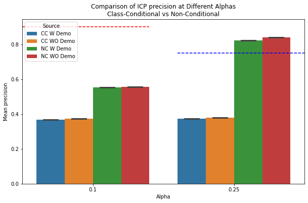

```python
import pandas as pd
import seaborn as sns
import matplotlib.pyplot as plt

# List of DataFrames
dfs = [df_precision_cc_w_demo_ip, df_precision_cc_wo_demo_ip, df_precision_nc_w_demo_ip, df_precision_nc_wo_demo_ip]

# Add a label to identify the source of each DataFrame
df_precision_cc_w_demo_ip['Source'] = 'CC W Demo'
df_precision_cc_wo_demo_ip['Source'] = 'CC WO Demo'
df_precision_nc_w_demo_ip['Source'] = 'NC W Demo'
df_precision_nc_wo_demo_ip['Source'] = 'NC WO Demo'

# Concatenate the DataFrames
df_concat = pd.concat(dfs)

df_concat = df_concat.rename(columns={'precision_alpha_0.1': '0.1', 'precision_alpha_0.25': '0.25'})

# Melt the DataFrame to long format for easier plotting with seaborn
df_melted = df_concat.melt(id_vars=['run', 'Source'],
                           value_vars=['0.1', '0.25'],
                           var_name='Alpha', value_name='precision')

# Plot the bars
plt.figure(figsize=(10, 6))
ax = sns.barplot(data=df_melted, x='Alpha', y='precision', hue='Source', capsize=.1)

# Add horizontal lines
ax.axhline(0.9, color='red', linestyle='--', xmin=0, xmax=0.45, label='0.9 for Alpha 0.1')
ax.axhline(0.75, color='blue', linestyle='--', xmin=0.55, xmax=1, label='0.75 for Alpha 0.25')

# Add labels and title
plt.title('Comparison of ICP precision at Different Alphas\nClass-Conditional vs Non-Conditional')
plt.ylabel('Mean precision')
plt.xlabel('Alpha')

# Display the plot
plt.show()
```

## Min, Median, Max

```python
import pandas as pd

# List of your dataframes
dfs = [
    df_precision_cc_w_demo_ip,
    df_precision_cc_wo_demo_ip,
    df_precision_nc_w_demo_ip,
    df_precision_nc_wo_demo_ip
]

# Prepare an empty list to collect stats
stats_list = []

# Iterate over each dataframe
for df in dfs:
    # Assuming the Source column is consistent across the dataframe, extract it from the first row
    source = df['Source'].iloc[0]

    # Compute statistics for alpha 0.1
    alpha_0_1_min = df['precision_alpha_0.1'].min()
    alpha_0_1_median = df['precision_alpha_0.1'].median()
    alpha_0_1_max = df['precision_alpha_0.1'].max()

    stats_list.append({
        'Source': source,
        'alpha': 0.1,
        'min': alpha_0_1_min,
        'median': alpha_0_1_median,
        'max': alpha_0_1_max
    })

    # Compute statistics for alpha 0.25
    alpha_0_25_min = df['precision_alpha_0.25'].min()
    alpha_0_25_median = df['precision_alpha_0.25'].median()
    alpha_0_25_max = df['precision_alpha_0.25'].max()

    stats_list.append({
        'Source': source,
        'alpha': 0.25,
        'min': alpha_0_25_min,
        'median': alpha_0_25_median,
        'max': alpha_0_25_max
    })

# Create a summary DataFrame from the list of dictionaries
summary_df = pd.DataFrame(stats_list)

summary_df.sort_values('max', ascending=False)
```

|  | Source | alpha | min | median | max |
| --- | --- | --- | --- | --- | --- |
| 7 | NC WO Demo | 0.25 | 0.839852 | 0.840050 | 0.840184 |
| 5 | NC W Demo | 0.25 | 0.823154 | 0.823564 | 0.823706 |
| 6 | NC WO Demo | 0.10 | 0.554291 | 0.554638 | 0.554822 |
| 4 | NC W Demo | 0.10 | 0.553120 | 0.553360 | 0.553655 |
| 3 | CC WO Demo | 0.25 | 0.378203 | 0.378605 | 0.378910 |
| 1 | CC W Demo | 0.25 | 0.373687 | 0.374003 | 0.374172 |
| 2 | CC WO Demo | 0.10 | 0.372510 | 0.372562 | 0.372636 |
| 0 | CC W Demo | 0.10 | 0.368048 | 0.368420 | 0.368470 |

# ICP - Per-Label Precision, Recall, and F1 Scores

```python
df = (
    df_icp__tpr_fpr_tnr_fnr
    .groupby(['name', 'run', 'label_idx', 'alpha'])[['tpr', 'fnr', 'fpr']]
    .sum()
    .assign(
        recall=lambda x: x['tpr'] / (x['tpr'] + x['fnr']),
        precision=lambda x: x['tpr'] / (x['tpr'] + x['fpr'])
    )
    .assign(f1=lambda x: 2 * (x['precision'] * x['recall']) / (x['precision'] + x['recall']))
    .reset_index()
)

label_mapping = {0: 'Anxiety', 1: 'Depression', 2: 'No Disorder'}

# Replace label_idx with actual label names
df['label'] = df['label_idx'].map(label_mapping)

# Drop the old label_idx column
df = df.drop(columns=['label_idx'])

# Aggregate recall, precision, and f1-score by ['name', 'label_idx', 'alpha']
df_summary = (
    df.groupby(['name', 'label', 'alpha'])[['recall', 'precision', 'f1']]
    .mean()
)

df_summary.round(2)
```

| name | label | alpha | recall | precision | f1 |
| --- | --- | --- | --- | --- | --- |
| df_ml_cc_w_demo_ip | Anxiety | 0.10 | 0.90 | 0.90 | 0.90 |
|  |  | 0.25 | 0.75 | 0.75 | 0.75 |
|  | Depression | 0.10 | 0.90 | 0.90 | 0.90 |
|  |  | 0.25 | 0.75 | 0.75 | 0.75 |
|  | No Disorder | 0.10 | 0.90 | 0.90 | 0.90 |
|  |  | 0.25 | 0.75 | 0.75 | 0.75 |
| df_ml_cc_wo_demo_ip | Anxiety | 0.10 | 0.90 | 0.90 | 0.90 |
|  |  | 0.25 | 0.75 | 0.75 | 0.75 |
|  | Depression | 0.10 | 0.90 | 0.90 | 0.90 |
|  |  | 0.25 | 0.75 | 0.75 | 0.75 |
|  | No Disorder | 0.10 | 0.90 | 0.90 | 0.90 |
|  |  | 0.25 | 0.75 | 0.75 | 0.75 |
| df_ml_nc_w_demo_ip | Anxiety | 0.10 | 0.47 | 0.97 | 0.63 |
|  |  | 0.25 | 0.11 | 0.39 | 0.17 |
|  | Depression | 0.10 | 0.43 | 0.98 | 0.59 |
|  |  | 0.25 | 0.08 | 0.30 | 0.14 |
|  | No Disorder | 0.10 | 0.88 | 0.96 | 0.92 |
|  |  | 0.25 | 0.71 | 0.90 | 0.79 |
| df_ml_nc_wo_demo_ip | Anxiety | 0.10 | 0.47 | 0.97 | 0.63 |
|  |  | 0.25 | 0.12 | 0.41 | 0.18 |
|  | Depression | 0.10 | 0.42 | 0.98 | 0.59 |
|  |  | 0.25 | 0.07 | 0.29 | 0.12 |
|  | No Disorder | 0.10 | 0.88 | 0.97 | 0.92 |
|  |  | 0.25 | 0.70 | 0.92 | 0.79 |

# Multi-Label MAPIE

```python
recall_cols = ['base_recall_samples', 'crc_recall_samples', 'rcps_recall_samples','ltt_recall_samples']
precision_cols = ['base_precision_samples', 'crc_precision_samples', 'rcps_precision_samples', 'ltt_precision_samples']
pred_set_size_cols = ['base_avg_prediction_set_size', 'crc_avg_prediction_set_size', 'rcps_avg_prediction_set_size', 'ltt_avg_prediction_set_size']
tot_fp_cols = ['base_total_false_positives', 'crc_total_false_positives', 'rcps_total_false_positives', 'ltt_total_false_positives']
tot_fn_cols = ['base_total_false_negatives', 'crc_total_false_negatives', 'rcps_total_false_negatives', 'ltt_total_false_negatives']

crc_cols = ['crc_recall_samples', 'crc_precision_samples', 'crc_avg_prediction_set_size', 'crc_total_false_positives', 'crc_total_false_negatives']
rcps_cols = ['rcps_recall_samples', 'rcps_precision_samples', 'rcps_avg_prediction_set_size', 'rcps_total_false_positives', 'rcps_total_false_negatives']
ltt_cols = ['ltt_recall_samples', 'ltt_precision_samples', 'ltt_avg_prediction_set_size', 'ltt_total_false_positives', 'ltt_total_false_negatives']
```

# Recall - CRC/RCPS vs Base Model

```python
df=mp
w=df[df['with_demographics']==True].reset_index(drop=True)
wo=df[df['with_demographics']==False].reset_index(drop=True)
```

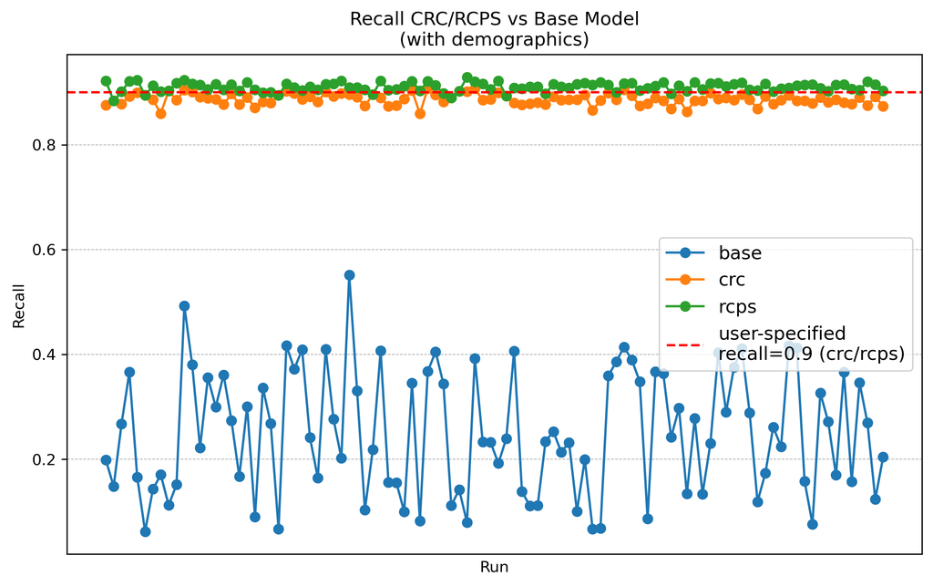

```python
import matplotlib.pyplot as plt
import matplotlib.ticker as ticker

# remove ltt to declutter
df=w[recall_cols[:3]]

# Create a large figure for publication quality
fig, ax = plt.subplots(figsize=(10, 6), dpi=300)


# Plot each column on the same axis
for column in df.columns:
    ax.plot(df.index, df[column], marker='o', label=column.split('_')[0])

# Adding a horizontal line at y=0.5 for user-specified level
ax.axhline(y=0.9, color='r', linestyle='--', label='user-specified\nrecall=0.9 (crc/rcps)')

ax.set_xticks([])  # Removes x-axis tick labels

# Adding labels and legend
plt.xlabel('Run')
plt.ylabel('Recall')
plt.title('Recall CRC/RCPS vs Base Model\n(with demographics)')


# Improving layout and readability
ax.grid(True, which='both', linestyle='--', linewidth=0.5)
ax.legend(loc='best', fontsize=12)

# Save the figure with high resolution
plt.savefig('recall_1_publication_quality_plot.png', bbox_inches='tight')
```

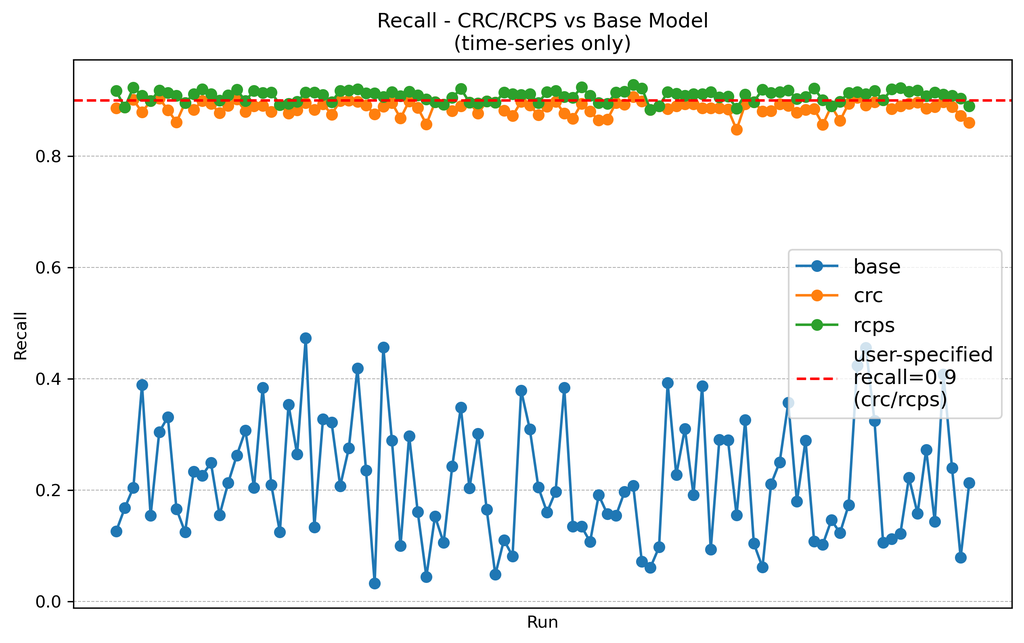

```python
import matplotlib.pyplot as plt
import matplotlib.ticker as ticker

# remove ltt to declutter
df=wo[recall_cols[:3]]

# Create a large figure for publication quality
fig, ax = plt.subplots(figsize=(10, 6), dpi=300)


# Plot each column on the same axis
for column in df.columns:
    ax.plot(df.index, df[column], marker='o', label=column.split('_')[0])

# Adding a horizontal line at y=0.5 for user-specified level
ax.axhline(y=0.9, color='r', linestyle='--', label='user-specified\nrecall=0.9\n(crc/rcps)')

ax.set_xticks([])  # Removes x-axis tick labels

# Adding labels and legend
plt.xlabel('Run')
plt.ylabel('Recall')
plt.title('Recall - CRC/RCPS vs Base Model\n(time-series only)')

# Improving layout and readability
ax.grid(True, which='both', linestyle='--', linewidth=0.5)
ax.legend(loc='best', fontsize=12)

# Save the figure with high resolution
plt.savefig('recall_2_publication_quality_plot.png', bbox_inches='tight')
```

# Prediction Set Size - CRC/RCPS vs Base Model

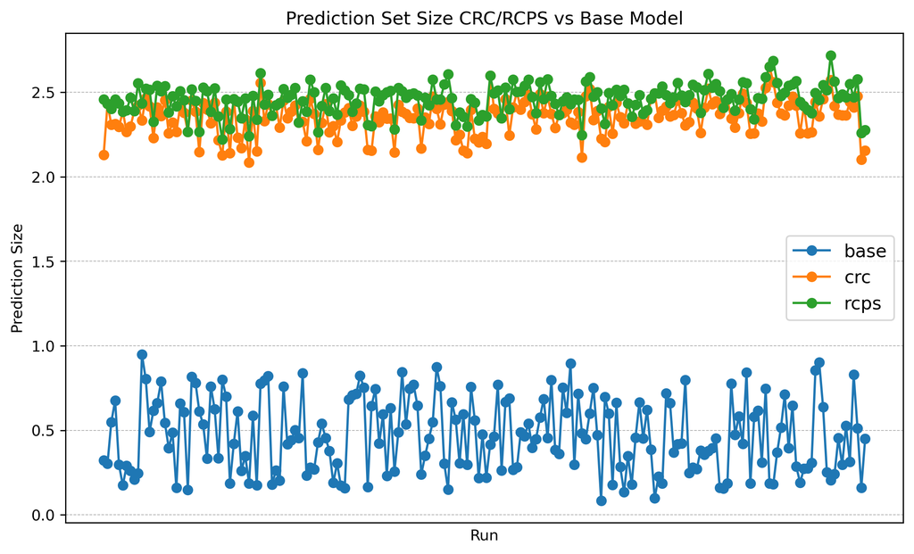

```python
import matplotlib.pyplot as plt
import matplotlib.ticker as ticker

# remove ltt to declutter
df=mp[pred_set_size_cols[:3]]

# Create a large figure for publication quality
fig, ax = plt.subplots(figsize=(10, 6), dpi=300)


# Plot each column on the same axis
for column in df.columns:
    ax.plot(df.index, df[column], marker='o', label=column.split('_')[0])

ax.set_xticks([])  # Removes x-axis tick labels

# Adding labels and legend
plt.xlabel('Run')
plt.ylabel('Prediction Size')
plt.title('Prediction Set Size CRC/RCPS vs Base Model')

# Improving layout and readability
ax.grid(True, which='both', linestyle='--', linewidth=0.5)
ax.legend(loc='best', fontsize=12)

# Save the figure with high resolution
plt.savefig('pss_publication_quality_plot.png', bbox_inches='tight')
```

# False Negatives - CRC/RCPS vs Base Model

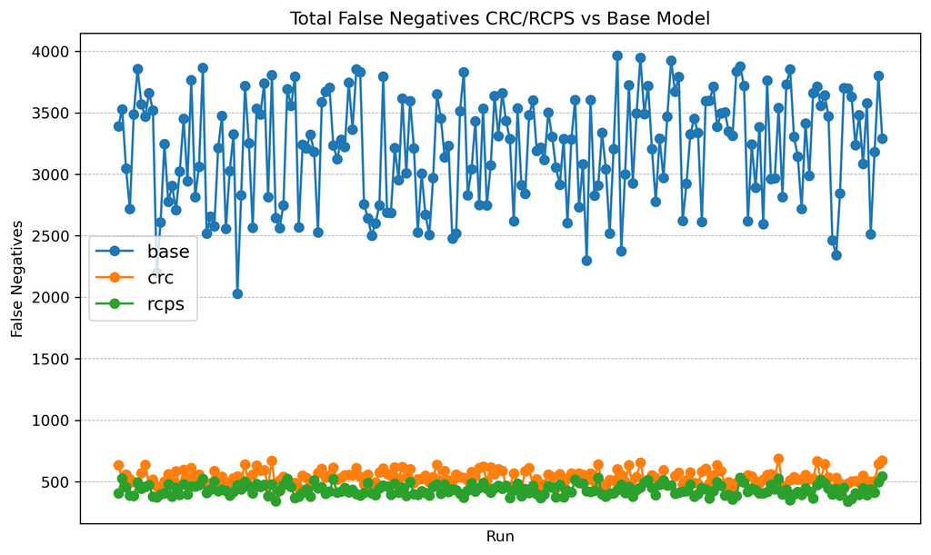

```python
import matplotlib.pyplot as plt
import matplotlib.ticker as ticker

# remove ltt to declutter
df=mp[tot_fn_cols[:3]]

# Create a large figure for publication quality
fig, ax = plt.subplots(figsize=(10, 6), dpi=300)


# Plot each column on the same axis
for column in df.columns:
    ax.plot(df.index, df[column], marker='o', label=column.split('_')[0])

ax.set_xticks([])  # Removes x-axis tick labels

# Adding labels and legend
plt.xlabel('Run')
plt.ylabel('False Negatives')
plt.title('Total False Negatives CRC/RCPS vs Base Model')

# Improving layout and readability
ax.grid(True, which='both', linestyle='--', linewidth=0.5)
ax.legend(loc='best', fontsize=12)

# Save the figure with high resolution
plt.savefig('tfn1_publication_quality_plot.png', bbox_inches='tight')
```

# False Positives - CRC/RCPS vs Base Model

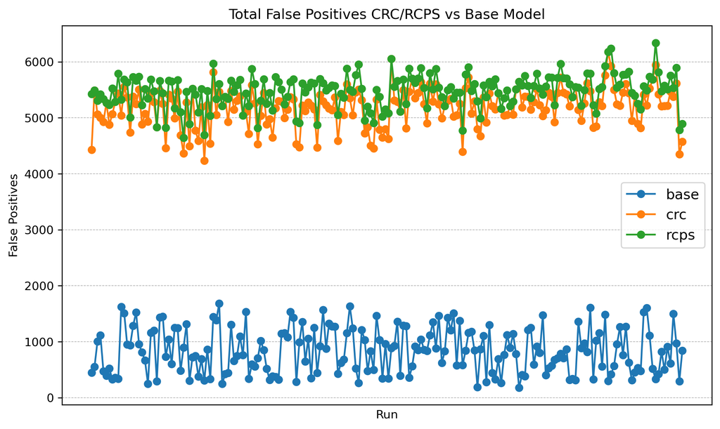

```python
import matplotlib.pyplot as plt
import matplotlib.ticker as ticker

# remove ltt to declutter
df=mp[tot_fp_cols[:3]]

# Create a large figure for publication quality
fig, ax = plt.subplots(figsize=(10, 6), dpi=300)


# Plot each column on the same axis
for column in df.columns:
    ax.plot(df.index, df[column], marker='o', label=column.split('_')[0])

ax.set_xticks([])  # Removes x-axis tick labels

# Adding labels and legend
plt.xlabel('Run')
plt.ylabel('False Positives')
plt.title('Total False Positives CRC/RCPS vs Base Model')

# Improving layout and readability
ax.grid(True, which='both', linestyle='--', linewidth=0.5)
ax.legend(loc='best', fontsize=12)

# Save the figure with high resolution
plt.savefig('tfp1_publication_quality_plot.png', bbox_inches='tight')
```

# Overall Precision/Recall

```python
datasets = {
    0.1: mp,
    0.25: mp_025
}

processed_dfs = []
for alpha, df in datasets.items():
    df_w = df[df['with_demographics'] == True].copy()
    df_wo = df[df['with_demographics'] == False].copy()

    # Assign alpha values
    df_w['alpha'] = alpha
    df_wo['alpha'] = alpha

    processed_dfs.extend([df_w, df_wo])

# Concatenate all processed dataframes
combined_df = pd.concat(processed_dfs, ignore_index=True)

# Define masks
samples_mask = combined_df.columns[combined_df.columns.str.endswith('_samples')]
methods = ['crc', 'rcps', 'ltt']
method_masks = {method: combined_df.columns[combined_df.columns.str.startswith(method)] for method in methods}

# Group and aggregate results
grouped_df = combined_df.groupby(['with_demographics', 'alpha'])
results = {
    method: grouped_df[samples_mask.intersection(method_masks[method])].agg(['min', 'mean', 'median', 'max']).round(2)
    for method in methods
}
```

## CRC

```python
results['crc']
```

| with_demographics | alpha | crc_recall_samples min | crc_recall_samples mean | crc_recall_samples median | crc_recall_samples max | crc_precision_samples min | crc_precision_samples mean | crc_precision_samples median | crc_precision_samples max |
| --- | --- | --- | --- | --- | --- | --- | --- | --- | --- |
| False | 0.10 | 0.85 | 0.89 | 0.89 | 0.91 | 0.38 | 0.43 | 0.43 | 0.49 |
|  | 0.25 | 0.65 | 0.73 | 0.73 | 0.76 | 0.40 | 0.48 | 0.48 | 0.60 |
| True | 0.10 | 0.86 | 0.89 | 0.89 | 0.91 | 0.40 | 0.44 | 0.44 | 0.51 |
|  | 0.25 | 0.68 | 0.73 | 0.73 | 0.76 | 0.43 | 0.50 | 0.49 | 0.64 |

## RCPS

```python
results['rcps']
```

| with_demographics | alpha | rcps_recall_samples min | rcps_recall_samples mean | rcps_recall_samples median | rcps_recall_samples max | rcps_precision_samples min | rcps_precision_samples mean | rcps_precision_samples median | rcps_precision_samples max |
| --- | --- | --- | --- | --- | --- | --- | --- | --- | --- |
| False | 0.10 | 0.88 | 0.91 | 0.91 | 0.93 | 0.38 | 0.42 | 0.42 | 0.47 |
|  | 0.25 | 0.71 | 0.75 | 0.76 | 0.79 | 0.39 | 0.47 | 0.47 | 0.59 |
| True | 0.10 | 0.88 | 0.91 | 0.91 | 0.93 | 0.40 | 0.43 | 0.43 | 0.49 |
|  | 0.25 | 0.70 | 0.75 | 0.76 | 0.79 | 0.42 | 0.49 | 0.49 | 0.63 |

## LTT

```python
results['ltt']
```

| with_demographics | alpha | ltt_recall_samples min | ltt_recall_samples mean | ltt_recall_samples median | ltt_recall_samples max | ltt_precision_samples min | ltt_precision_samples mean | ltt_precision_samples median | ltt_precision_samples max |
| --- | --- | --- | --- | --- | --- | --- | --- | --- | --- |
| False | 0.10 | 0.0 | 0.04 | 0.0 | 0.81 | 0.0 | 0.03 | 0.0 | 0.56 |
|  | 0.25 | 0.0 | 0.04 | 0.0 | 0.81 | 0.0 | 0.03 | 0.0 | 0.56 |
| True | 0.10 | 0.0 | 0.17 | 0.0 | 0.87 | 0.0 | 0.12 | 0.0 | 0.55 |
|  | 0.25 | 0.0 | 0.17 | 0.0 | 0.87 | 0.0 | 0.12 | 0.0 | 0.55 |

# Per-Label Precision, Recall, and F1 Scores

```python
def get_mean_precision_recall_f1(method_nm, df_rcps):
    """
    Calculate the mean precision, recall, and f1-score for a given method.

    Parameters:
        method_nm (str): The method name to filter on (e.g., 'rcps').
        df_rcps (pd.DataFrame): DataFrame containing the columns 'run', 'label_idx',
            'name', and metric columns (e.g., 'rcps_TP', 'rcps_FP', etc.).

    Returns:
        pd.DataFrame: A summary DataFrame with mean precision, recall, and f1-score
                      aggregated by 'name', 'label', and 'alpha'.
    """
    # Work on a copy to avoid modifying the original DataFrame
    df = df_rcps.copy()

    # Split the 'name' column into 'name' and 'alpha'
    df[['name', 'alpha']] = df['name'].str.rsplit('_', n=1, expand=True)
    df['alpha'] = df['alpha'].str.replace('0', '0.')

    # Melt the DataFrame to long format, keeping 'run', 'label_idx', 'name', 'alpha'
    df_melted = df.melt(id_vars=['run', 'label_idx', 'name', 'alpha'],
                        var_name='metric', value_name='value')

    # Extract 'method' and actual metric name from the 'metric' column
    df_melted[['method', 'metric']] = df_melted['metric'].str.split('_', n=1, expand=True)

    # Filter the DataFrame for the specified method
    df_melted = df_melted[df_melted['method'] == method_nm]

    # Pivot the DataFrame so that each metric (TP, FP, FN, etc.) becomes a column
    df_pivot = df_melted.pivot_table(index=['run', 'label_idx', 'name', 'alpha', 'method'],
                                     columns='metric', values='value').reset_index()

    # Calculate precision, recall, and f1-score with safeguards against division by zero
    df_pivot['precision'] = np.where((df_pivot['TP'] + df_pivot['FP']) == 0,
                                     np.nan,
                                     df_pivot['TP'] / (df_pivot['TP'] + df_pivot['FP']))
    df_pivot['recall'] = np.where((df_pivot['TP'] + df_pivot['FN']) == 0,
                                  np.nan,
                                  df_pivot['TP'] / (df_pivot['TP'] + df_pivot['FN']))
    df_pivot['f1'] = np.where((df_pivot['precision'] + df_pivot['recall']) == 0,
                              np.nan,
                              2 * (df_pivot['precision'] * df_pivot['recall']) /
                              (df_pivot['precision'] + df_pivot['recall']))

    # Map label indices to their corresponding disorder names
    label_mapping = {0: 'Anxiety', 1: 'Depression', 2: 'No Disorder'}
    df_pivot['label'] = df_pivot['label_idx'].map(label_mapping)
    df_pivot.drop(columns=['label_idx'], inplace=True)

    # Aggregate metrics by 'name', 'label', and 'alpha'
    df_summary = (
        df_pivot.groupby(['name', 'label', 'alpha'])[['precision', 'recall', 'f1']]
        .mean()
        .round(2)
        # .reset_index()
    )

    return df_summary
```

## CRC

```python
get_mean_precision_recall_f1('crc', df_rcps_crc__tp_fp_tn_fn)
```

| name | label | metric alpha | precision | recall | f1 |
| --- | --- | --- | --- | --- | --- |
| df_w_demo | Anxiety | 0.1 | 0.17 | 0.73 | 0.27 |
|  |  | 0.25 | 0.17 | 0.49 | 0.24 |
|  | Depression | 0.1 | 0.16 | 0.66 | 0.25 |
|  |  | 0.25 | 0.16 | 0.42 | 0.22 |
|  | No Disorder | 0.1 | 0.78 | 0.94 | 0.85 |
|  |  | 0.25 | 0.78 | 0.80 | 0.79 |
| df_wo_demo | Anxiety | 0.1 | 0.16 | 0.76 | 0.27 |
|  |  | 0.25 | 0.16 | 0.54 | 0.25 |
|  | Depression | 0.1 | 0.16 | 0.69 | 0.25 |
|  |  | 0.25 | 0.16 | 0.46 | 0.23 |
|  | No Disorder | 0.1 | 0.78 | 0.93 | 0.85 |
|  |  | 0.25 | 0.78 | 0.79 | 0.79 |

## RCPS

```python
get_mean_precision_recall_f1('rcps', df_rcps_crc__tp_fp_tn_fn)
```

| name | label | metric alpha | precision | recall | f1 |
| --- | --- | --- | --- | --- | --- |
| df_w_demo | Anxiety | 0.1 | 0.16 | 0.77 | 0.27 |
|  |  | 0.25 | 0.17 | 0.52 | 0.25 |
|  | Depression | 0.1 | 0.16 | 0.71 | 0.26 |
|  |  | 0.25 | 0.16 | 0.45 | 0.23 |
|  | No Disorder | 0.1 | 0.78 | 0.96 | 0.86 |
|  |  | 0.25 | 0.78 | 0.83 | 0.80 |
| df_wo_demo | Anxiety | 0.1 | 0.17 | 0.80 | 0.27 |
|  |  | 0.25 | 0.16 | 0.57 | 0.25 |
|  | Depression | 0.1 | 0.16 | 0.73 | 0.26 |
|  |  | 0.25 | 0.16 | 0.49 | 0.24 |
|  | No Disorder | 0.1 | 0.78 | 0.95 | 0.86 |
|  |  | 0.25 | 0.78 | 0.81 | 0.80 |

## LTT

```python
get_mean_precision_recall_f1('ltt', df_rcps_crc__tp_fp_tn_fn)
```

| name | label | metric alpha | precision | recall | f1 |
| --- | --- | --- | --- | --- | --- |
| df_w_demo | Anxiety | 0.1 | 0.17 | 0.10 | 0.24 |
|  |  | 0.25 | 0.17 | 0.10 | 0.24 |
|  | Depression | 0.1 | 0.16 | 0.08 | 0.22 |
|  |  | 0.25 | 0.16 | 0.08 | 0.22 |
|  | No Disorder | 0.1 | 0.78 | 0.20 | 0.82 |
|  |  | 0.25 | 0.78 | 0.20 | 0.82 |
| df_wo_demo | Anxiety | 0.1 | 0.16 | 0.02 | 0.23 |
|  |  | 0.25 | 0.16 | 0.02 | 0.23 |
|  | Depression | 0.1 | 0.16 | 0.02 | 0.22 |
|  |  | 0.25 | 0.16 | 0.02 | 0.22 |
|  | No Disorder | 0.1 | 0.78 | 0.04 | 0.81 |
|  |  | 0.25 | 0.78 | 0.04 | 0.81 |

# Recall Coverage Distribution

### CRC

```python
w_demo = mp['with_demographics']==True
wo_demo = mp['with_demographics']==False
```

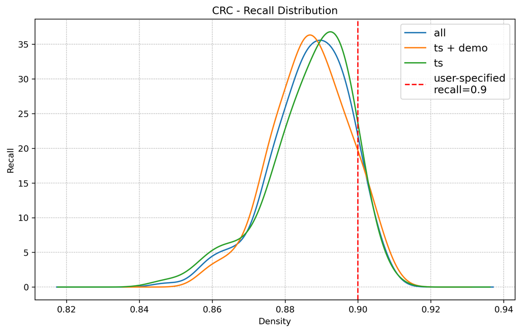

```python
import matplotlib.pyplot as plt
import matplotlib.ticker as ticker



# Create a large figure for publication quality
fig, ax = plt.subplots(figsize=(10, 6), dpi=300)


mp.loc[:,'crc_recall_samples'].plot(kind='kde',ax=ax,label='all')
mp[w_demo].loc[:,'crc_recall_samples'].plot(kind='kde',ax=ax,label='ts + demo')
mp[wo_demo].loc[:,'crc_recall_samples'].plot(kind='kde',ax=ax,label='ts')


# Adding a vertical line at user-specified level
ax.axvline(x=0.9, color='r', linestyle='--', label='user-specified\nrecall=0.9')

# Adding labels and legend
plt.xlabel('Density')
plt.ylabel('Recall')
plt.title('CRC - Recall Distribution')

# Improving layout and readability
ax.grid(True, which='both', linestyle='--', linewidth=0.5)
ax.legend(loc='best', fontsize=12)

# Save the figure with high resolution
plt.savefig('recall_distro_crc_publication_quality_plot.png', bbox_inches='tight')
```

### RCPS

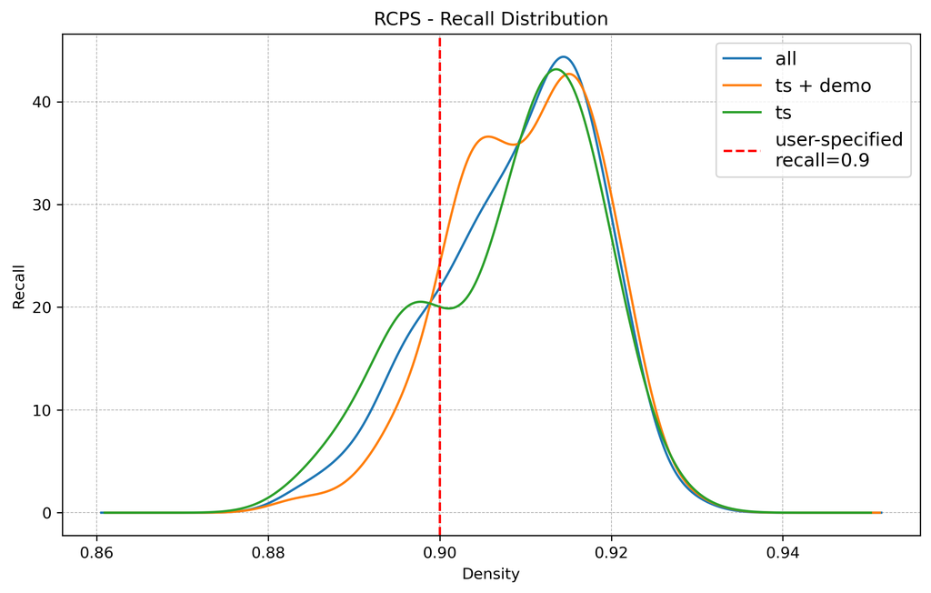

```python
import matplotlib.pyplot as plt
import matplotlib.ticker as ticker



# Create a large figure for publication quality
fig, ax = plt.subplots(figsize=(10, 6), dpi=300)


mp.loc[:,'rcps_recall_samples'].plot(kind='kde',ax=ax,label='all')
mp[w_demo].loc[:,'rcps_recall_samples'].plot(kind='kde',ax=ax,label='ts + demo')
mp[wo_demo].loc[:,'rcps_recall_samples'].plot(kind='kde',ax=ax,label='ts')

# Adding a vertical line at user-specified level
ax.axvline(x=0.9, color='r', linestyle='--', label='user-specified\nrecall=0.9')

# Adding labels and legend
plt.xlabel('Density')
plt.ylabel('Recall')
plt.title('RCPS - Recall Distribution')

# Improving layout and readability
ax.grid(True, which='both', linestyle='--', linewidth=0.5)
ax.legend(loc='best', fontsize=12)

# Save the figure with high resolution
plt.savefig('recall_distro_rcps_publication_quality_plot.png', bbox_inches='tight')
```

### RCPS + CRC

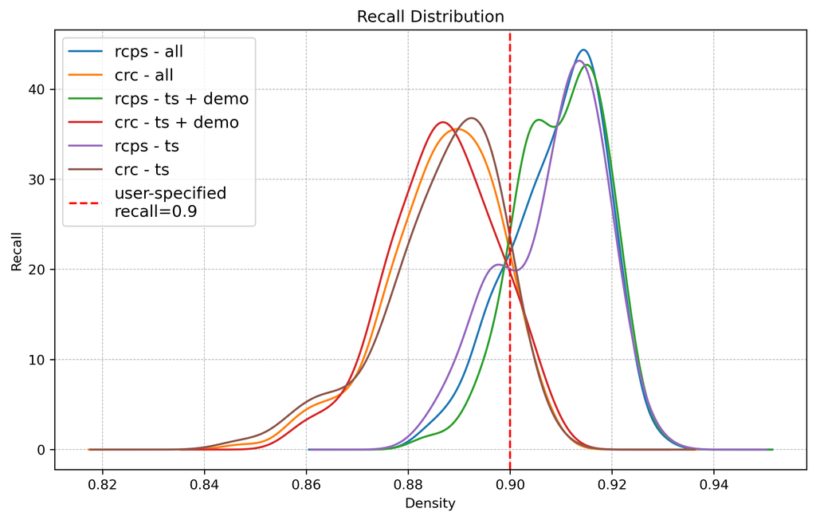

```python
import matplotlib.pyplot as plt
import matplotlib.ticker as ticker



# Create a large figure for publication quality
fig, ax = plt.subplots(figsize=(10, 6), dpi=300)


mp.loc[:,'rcps_recall_samples'].plot(kind='kde',ax=ax,label='rcps - all')
mp.loc[:,'crc_recall_samples'].plot(kind='kde',ax=ax,label='crc - all')

mp[w_demo].loc[:,'rcps_recall_samples'].plot(kind='kde',ax=ax,label='rcps - ts + demo')
mp[w_demo].loc[:,'crc_recall_samples'].plot(kind='kde',ax=ax,label='crc - ts + demo')

mp[wo_demo].loc[:,'rcps_recall_samples'].plot(kind='kde',ax=ax,label='rcps - ts')
mp[wo_demo].loc[:,'crc_recall_samples'].plot(kind='kde',ax=ax,label='crc - ts')


# Adding a vertical line at user-specified level
ax.axvline(x=0.9, color='r', linestyle='--', label='user-specified\nrecall=0.9')

# Adding labels and legend
plt.xlabel('Density')
plt.ylabel('Recall')
plt.title('Recall Distribution')

# Improving layout and readability
ax.grid(True, which='both', linestyle='--', linewidth=0.5)
ax.legend(loc='best', fontsize=12)

# Save the figure with high resolution
plt.savefig('recall_distro_rcps-crc_publication_quality_plot.png', bbox_inches='tight')
```

# Recall (RCPS & CRC)

(`user-specified recall=0.9`)

```python
mp.loc[:,recall_cols].describe().iloc[[1,5],:]
```

|  | base_recall_samples | crc_recall_samples | rcps_recall_samples | ltt_recall_samples |
| --- | --- | --- | --- | --- |
| mean | 0.234880 | 0.886668 | 0.909173 | 0.105911 |
| 50% | 0.222222 | 0.887621 | 0.910825 | 0.000000 |

#### w_demo

```python
mp[w_demo].loc[:,recall_cols].describe().iloc[[1,5],:]
```

|  | base_recall_samples | crc_recall_samples | rcps_recall_samples | ltt_recall_samples |
| --- | --- | --- | --- | --- |
| mean | 0.250953 | 0.886760 | 0.910022 | 0.1747 |
| 50% | 0.240427 | 0.886306 | 0.910810 | 0.0000 |

#### wo_demo

```python
mp[wo_demo].loc[:,recall_cols].describe().iloc[[1,5],:]
```

|  | base_recall_samples | crc_recall_samples | rcps_recall_samples | ltt_recall_samples |
| --- | --- | --- | --- | --- |
| mean | 0.218807 | 0.886575 | 0.908325 | 0.037122 |
| 50% | 0.204689 | 0.889277 | 0.911014 | 0.000000 |

# Precision (LTT)

(`user-specified precision=0.5`)

```python
mp.loc[:,precision_cols].describe().iloc[[1,5],:]
```

|  | base_precision_samples | crc_precision_samples | rcps_precision_samples | ltt_precision_samples |
| --- | --- | --- | --- | --- |
| mean | 0.236992 | 0.438199 | 0.427220 | 0.075483 |
| 50% | 0.226612 | 0.435804 | 0.425115 | 0.000000 |

### Runs Where LTT Did Not Abstain All Predictions

```python
ltt_not_all_abstain = mp['ltt_precision_micro']!=0
```

```python
mp[ltt_not_all_abstain].loc[:,precision_cols].describe().iloc[[1,5],:]
```

|  | base_precision_samples | crc_precision_samples | rcps_precision_samples | ltt_precision_samples |
| --- | --- | --- | --- | --- |
| mean | 0.323306 | 0.469870 | 0.450517 | 0.539165 |
| 50% | 0.368192 | 0.470764 | 0.449534 | 0.540228 |

# CRC

## Coverage

- Out of 200 models
  - 100 time-series + demographics
  - 100 time-series

```python
mp.loc[:,crc_cols].describe().loc[['min', '50%', 'max']]
```

|  | crc_recall_samples | crc_precision_samples | crc_avg_prediction_set_size | crc_total_false_positives | crc_total_false_negatives |
| --- | --- | --- | --- | --- | --- |
| min | 0.847260 | 0.377855 | 2.084586 | 4232.0 | 399.0 |
| 50% | 0.887621 | 0.435804 | 2.372059 | 5229.5 | 530.5 |
| max | 0.907158 | 0.510014 | 2.652244 | 6178.0 | 687.0 |

#### w_demo

```python
mp[w_demo].loc[:,crc_cols].describe().loc[['min', '50%', 'max']]
```

|  | crc_recall_samples | crc_precision_samples | crc_avg_prediction_set_size | crc_total_false_positives | crc_total_false_negatives |
| --- | --- | --- | --- | --- | --- |
| min | 0.859295 | 0.401871 | 2.084586 | 4232.0 | 399.0 |
| 50% | 0.886306 | 0.439284 | 2.346278 | 5150.5 | 538.0 |
| max | 0.907158 | 0.510014 | 2.556243 | 5814.0 | 671.0 |

#### wo_demo

```python
mp[wo_demo].loc[:,crc_cols].describe().loc[['min', '50%', 'max']]
```

|  | crc_recall_samples | crc_precision_samples | crc_avg_prediction_set_size | crc_total_false_positives | crc_total_false_negatives |
| --- | --- | --- | --- | --- | --- |
| min | 0.847260 | 0.377855 | 2.102233 | 4350.0 | 435.0 |
| 50% | 0.889277 | 0.431377 | 2.377402 | 5289.0 | 517.0 |
| max | 0.906561 | 0.486350 | 2.652244 | 6178.0 | 687.0 |

### CRC % with_demographics vs wo_demographics

```python
mp[w_demo].loc[:,crc_cols].describe().loc[['min', '50%', 'max']] / mp[wo_demo].loc[:,crc_cols].describe().loc[['min', '50%', 'max']]
```

|  | crc_recall_samples | crc_precision_samples | crc_avg_prediction_set_size | crc_total_false_positives | crc_total_false_negatives |
| --- | --- | --- | --- | --- | --- |
| min | 1.014205 | 1.063558 | 0.991606 | 0.972874 | 0.917241 |
| 50% | 0.996658 | 1.018330 | 0.986908 | 0.973814 | 1.040619 |
| max | 1.000659 | 1.048657 | 0.963804 | 0.941081 | 0.976710 |

# RCPS

## Coverage

- Out of 200 models
  - 100 time-series + demographics
  - 100 time-series

```python
mp.loc[:,rcps_cols].describe().loc[['min', '50%', 'max']]
```

|  | rcps_recall_samples | rcps_precision_samples | rcps_avg_prediction_set_size | rcps_total_false_positives | rcps_total_false_negatives |
| --- | --- | --- | --- | --- | --- |
| min | 0.883271 | 0.377855 | 2.220762 | 4641.0 | 340.0 |
| 50% | 0.910825 | 0.425115 | 2.468485 | 5513.5 | 431.5 |
| max | 0.928744 | 0.493383 | 2.717660 | 6337.0 | 545.0 |

#### w_demo

```python
mp[w_demo].loc[:,rcps_cols].describe().loc[['min', '50%', 'max']]
```

|  | rcps_recall_samples | rcps_precision_samples | rcps_avg_prediction_set_size | rcps_total_false_positives | rcps_total_false_negatives |
| --- | --- | --- | --- | --- | --- |
| min | 0.883615 | 0.396499 | 2.220762 | 4641.0 | 341.0 |
| 50% | 0.910810 | 0.431262 | 2.458037 | 5459.5 | 436.0 |
| max | 0.928744 | 0.493383 | 2.614101 | 5971.0 | 526.0 |

#### wo_demo

```python
mp[wo_demo].loc[:,rcps_cols].describe().loc[['min', '50%', 'max']]
```

|  | rcps_recall_samples | rcps_precision_samples | rcps_avg_prediction_set_size | rcps_total_false_positives | rcps_total_false_negatives |
| --- | --- | --- | --- | --- | --- |
| min | 0.883271 | 0.377855 | 2.245972 | 4774.0 | 340.0 |
| 50% | 0.911014 | 0.421836 | 2.482458 | 5553.0 | 427.5 |
| max | 0.927938 | 0.465897 | 2.717660 | 6337.0 | 545.0 |

### RCPS % with_demographics vs wo_demographics

```python
mp[w_demo].loc[:,rcps_cols].describe().loc[['min', '50%', 'max']] / mp[wo_demo].loc[:,rcps_cols].describe().loc[['min', '50%', 'max']]
```

|  | rcps_recall_samples | rcps_precision_samples | rcps_avg_prediction_set_size | rcps_total_false_positives | rcps_total_false_negatives |
| --- | --- | --- | --- | --- | --- |
| min | 1.000390 | 1.049341 | 0.988775 | 0.972141 | 1.002941 |
| 50% | 0.999776 | 1.022345 | 0.990163 | 0.983162 | 1.019883 |
| max | 1.000869 | 1.058997 | 0.961894 | 0.942244 | 0.965138 |

# Recall (CRC vs RCPS)

## Coverage

- Out of 200 models
  - 100 time-series + demographics
  - 100 time-series

```python
df=mp
w=df[df['with_demographics']==True].reset_index(drop=True)
wo=df[df['with_demographics']==False].reset_index(drop=True)
```

### 90% Recall

##### CRC

```python
(w['crc_recall_samples'] >= 0.9).sum()
```

```
11
```

```python
(wo['crc_recall_samples'] >= 0.9).sum()
```

```
6
```

##### RCPS

```python
(w['rcps_recall_samples'] >= 0.9).sum()
```

```
89
```

```python
(wo['rcps_recall_samples'] >= 0.9).sum()
```

```
75
```

### 89% Recall

##### CRC

```python
(w['crc_recall_samples'] >= 0.89).sum()
```

```
39
```

```python
(wo['crc_recall_samples'] >= 0.89).sum()
```

```
45
```

##### RCPS

```python
(w['rcps_recall_samples'] >= 0.89).sum()
```

```
98
```

```python
(wo['rcps_recall_samples'] >= 0.89).sum()
```

```
94
```

### 88% Recall

##### CRC

```python
(w['crc_recall_samples'] >= 0.88).sum()
```

```
74
```

```python
(wo['crc_recall_samples'] >= 0.88).sum()
```

```
76
```

##### RCPS

```python
(w['rcps_recall_samples'] >= 0.88).sum()
```

```
100
```

```python
(wo['rcps_recall_samples'] >= 0.88).sum()
```

```
100
```

# LTT

```python
ltt_not_all_abstain = (mp['ltt_precision_micro']!=0)
```

```python
mp[ltt_not_all_abstain].shape[0]
```

```
28
```

```python
mp[ltt_not_all_abstain & w_demo].shape[0]
```

```
23
```

```python
mp[ltt_not_all_abstain & wo_demo].shape[0]
```

```
5
```

28/200 LTT did not abstain

- 5 wo_demo
- 23 w_demo

```python
mp[ltt_not_all_abstain].loc[:,ltt_cols].describe().iloc[[1,5],:]
```

|  | ltt_recall_samples | ltt_precision_samples | ltt_avg_prediction_set_size | ltt_total_false_positives | ltt_total_false_negatives |
| --- | --- | --- | --- | --- | --- |
| mean | 0.756508 | 0.539165 | 1.647434 | 3161.178571 | 1146.321429 |
| 50% | 0.764258 | 0.540228 | 1.675604 | 3194.500000 | 1119.000000 |

#### w_demo

```python
mp[ltt_not_all_abstain & w_demo].loc[:,ltt_cols].describe().iloc[[1,5],:]
```

|  | ltt_recall_samples | ltt_precision_samples | ltt_avg_prediction_set_size | ltt_total_false_positives | ltt_total_false_negatives |
| --- | --- | --- | --- | --- | --- |
| mean | 0.759566 | 0.538436 | 1.658712 | 3190.173913 | 1131.956522 |
| 50% | 0.767436 | 0.540357 | 1.692947 | 3232.000000 | 1118.000000 |

#### wo_demo

```python
mp[ltt_not_all_abstain & wo_demo].loc[:,ltt_cols].describe().iloc[[1,5],:]
```

|  | ltt_recall_samples | ltt_precision_samples | ltt_avg_prediction_set_size | ltt_total_false_positives | ltt_total_false_negatives |
| --- | --- | --- | --- | --- | --- |
| mean | 0.742441 | 0.542521 | 1.595554 | 3027.8 | 1212.4 |
| 50% | 0.739667 | 0.540100 | 1.594740 | 3029.0 | 1231.0 |

### LTT % with_demographics vs wo_demographics

```python
mp[ltt_not_all_abstain & w_demo].loc[:,ltt_cols].describe().iloc[[1,5],:] / mp[ltt_not_all_abstain & wo_demo].loc[:,ltt_cols].describe().iloc[[1,5],:]
```

|  | ltt_recall_samples | ltt_precision_samples | ltt_avg_prediction_set_size | ltt_total_false_positives | ltt_total_false_negatives |
| --- | --- | --- | --- | --- | --- |
| mean | 1.023066 | 0.992470 | 1.039584 | 1.053628 | 0.933649 |
| 50% | 1.037542 | 1.000475 | 1.061582 | 1.067019 | 0.908205 |

#### LTT (not abstain) Prediction Set Size

```python
mp[ltt_not_all_abstain].loc[:,pred_set_size_cols].describe().iloc[[-3],:]
```

|  | base_avg_prediction_set_size | crc_avg_prediction_set_size | rcps_avg_prediction_set_size | ltt_avg_prediction_set_size |
| --- | --- | --- | --- | --- |
| 50% | 0.611968 | 2.217147 | 2.362831 | 1.675604 |

#### w_demo

```python
mp[ltt_not_all_abstain & w_demo].loc[:,pred_set_size_cols].describe().iloc[[-3],:]
```

|  | base_avg_prediction_set_size | crc_avg_prediction_set_size | rcps_avg_prediction_set_size | ltt_avg_prediction_set_size |
| --- | --- | --- | --- | --- |
| 50% | 0.611439 | 2.217859 | 2.367714 | 1.692947 |

#### wo_demo

```python
mp[ltt_not_all_abstain & wo_demo].loc[:,pred_set_size_cols].describe().iloc[[-3],:]
```

|  | base_avg_prediction_set_size | crc_avg_prediction_set_size | rcps_avg_prediction_set_size | ltt_avg_prediction_set_size |
| --- | --- | --- | --- | --- |
| 50% | 0.698498 | 2.206813 | 2.356951 | 1.59474 |

# Prediction Set Size (per patient)

### (CRC vs RCPS - CRC smaller, but having slightly lower recall)

```python
mp.loc[:,pred_set_size_cols].describe().iloc[[1,5],:3]
```

|  | base_avg_prediction_set_size | crc_avg_prediction_set_size | rcps_avg_prediction_set_size |
| --- | --- | --- | --- |
| mean | 0.470955 | 2.354910 | 2.459590 |
| 50% | 0.453678 | 2.372059 | 2.468485 |

#### w_demo

```python
mp[w_demo].loc[:,pred_set_size_cols].describe().iloc[[1,5],:3]
```

|  | base_avg_prediction_set_size | crc_avg_prediction_set_size | rcps_avg_prediction_set_size |
| --- | --- | --- | --- |
| mean | 0.491012 | 2.326654 | 2.439089 |
| 50% | 0.489784 | 2.346278 | 2.458037 |

#### wo_demo

```python
mp[wo_demo].loc[:,pred_set_size_cols].describe().iloc[[1,5],:3]
```

|  | base_avg_prediction_set_size | crc_avg_prediction_set_size | rcps_avg_prediction_set_size |
| --- | --- | --- | --- |
| mean | 0.450898 | 2.383167 | 2.480092 |
| 50% | 0.436116 | 2.377402 | 2.482458 |

# False Positives (LTT)

```python
mp.loc[:,tot_fp_cols].describe().iloc[[1,5],:]
```

|  | base_total_false_positives | crc_total_false_positives | rcps_total_false_positives | ltt_total_false_positives |
| --- | --- | --- | --- | --- |
| mean | 839.845 | 5185.03 | 5473.51 | 442.565 |
| 50% | 835.000 | 5229.50 | 5513.50 | 0.000 |

### Mean

```python
mp.loc[:,tot_fp_cols].describe().iloc[[1],[0,3]]
```

|  | base_total_false_positives | ltt_total_false_positives |
| --- | --- | --- |
| mean | 839.845 | 442.565 |

# False Negatives (RCPS & CRC)

```python
mp.loc[:,tot_fn_cols].describe().iloc[[1,5],:]
```

|  | base_total_false_negatives | crc_total_false_negatives | rcps_total_false_negatives | ltt_total_false_negatives |
| --- | --- | --- | --- | --- |
| mean | 3202.78 | 535.705 | 434.56 | 3699.65 |
| 50% | 3244.00 | 530.500 | 431.50 | 4111.00 |

### Median

```python
mp.loc[:,tot_fn_cols].describe().iloc[[-3],:3]
```

|  | base_total_false_negatives | crc_total_false_negatives | rcps_total_false_negatives |
| --- | --- | --- | --- |
| 50% | 3244.0 | 530.5 | 431.5 |